# Statistics and Sampling Variability

MAT150 - Stats for Life Sciences

2022-09-29

### R Commands covered in this lesson

`mean`,`sample`, `read.table`, `hist`, `choose`, `for`

## Statistics

> DEFINITION: A **statistic** is a quantity computed from sample data. The sample mean, $\bar{x}$, sample median, and the sample standard deviation are all examples of statistics. The value of the statistic will vary depending on the sample. This variability is called **sample variability**.

Let $n$ be the sample size. The **sample mean** is defined as:
$$\bar{x} = \frac{1}{n} \sum_{i=1}^n x_i$$

### Example 8.1

Twenty students book expenses are given in the data below. We will take samples of this data and examine it.

```r
# Read data
books = read.table('https://tinyurl.com/bdes8td3', header=TRUE)
```

The population mean is:

```r
# Calculate (population) mean of the Amount spent on books
mean(books$Amount)
```

```
## [1] 360.25
```

Take a sample of 5 students and calculate its mean (use as estimate of population mean).

```r
# Sample of 5 expense amounts
x = sample(books$Amount, 5)

# (Sample) Mean of those
mean(x)
```

```
## [1] 364.4
```

Now, take 100 different samples (of 5) and calculate the mean of each sample.

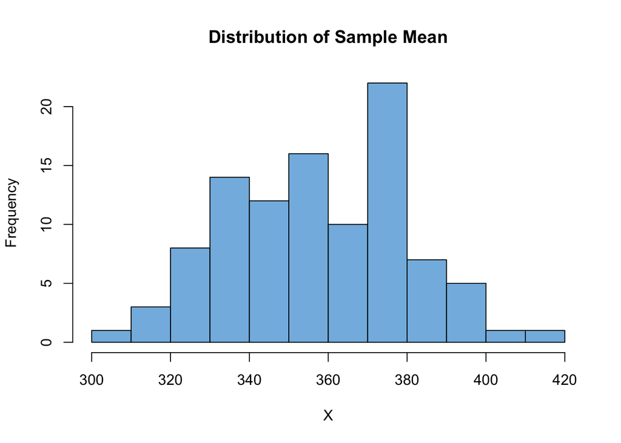

```r
N = 1:100

# Create vector of zeros
X = rep(0, length(N))
for (s in N) {
  X[s] = mean(sample(books$Amount,5))
}

# Show distribution using a Histogram
hist(X, main = 'Distribution of Sample Mean', col="#83bae2")
```

Note: there are $\binom{20}{5}$ unique samples of 5.

```r
choose(20,5)
```

```
## [1] 15504
```

For completeness, calculate the **median** and **standard deviation** of a random sample.

```r
median(x)
```

```
## [1] 367
```

```r
sd(x)
```

```
## [1] 68.10874
```

> **DEFINITION**: The distribution that would be formed by considering the value of a sample statistics for every possible different sample of a given size from a population is called the **sampling distribution**.

> **THEOREM**: If a random sample of $n$ measurements is drawn from a population that is normally distributed with mean $\mu$ and standard deviation $\sigma$, then the sampling distrubition of the sample mean $\bar{x}$ will be normally distrubted with mean $\mu$ and standard deviation (called the **standard error**) SE$(\bar{x}) = \sigma / \sqrt{n}$.

> **CENTRAL LIMIT THEOREM**: If a random sample of $n$ measurements is drawn from a **nonnormal** population with fininte mean $\mu$ and standard deviation $\sigma$, then when $n$ is large, the sampling distribution of the sample mean $\bar{x}$ will be approximately normally distrubted with mean $\mu$ and standard error SE$(\bar{x}) = \sigma / \sqrt{n}$.

### Exercises

**8.2** What is the difference between $\bar{x}$ and $\mu$? between $s$ and $\sigma$?

**8.3** For each of the following statements, identify the number that appears in boldface type as the value of either a population characteristic or a statistic:

1. A department store reports that **84%** of all customers who use the store’s credit plan pay their bills on time.
2. A sample of 100 students at a large university had a mean age of **24.1** years.
3. The Department of Motor Vehicles reports that **22%** of all vehicles registered in a particular state are imports.
4. A hospital reports that based on the 10 most recent cases, the mean length of stay for surgical patients is **6.4** days.
5. A consumer group, after testing 100 batteries of a certain brand, reported an average life of **63** hours of use.

### Summary

We would like to know the value of a population characteristic (i.e., the mean), *however*, it is not feasible (or reasonable) to obtain. Instead, we *sample* (take a subset), then calculate the value on the sample. If the sample is drawn randomly, we should expect (depending on sample size), that it is a reasonably good estimation to the actual value. If we take **ALL** random samples of a certain size, calculate the statistic, and create a histogram, we will see the histogram is fairly symmetric with one hump (i.e., normal). This histogram is a visualization of the *sample distribution*. The sample distribution of a statistics (i.e., sample mean $\bar{x}$) provides important information about variation in the values of the statistic.

### References

Peck, R., & Devore, J. L. (2011). *Statistics: The Exploration & Analysis of Data*. Cengage Learning.